# Lecture 2: Measuring Variability in R

Advanced Statistics for Social Sciences

# Introduction

In this notebook, we’ll learn how to: 1. Calculate basic measures of variability (range, IQR, variance, SD) 2. Understand why we use n-1 for sample variance (simulation) 3. Use Z-scores to compare different distributions

# 1. Measures of Variability

Let’s create some sample data to work with:

```r
# Simulated test scores for a class
scores <- c(65, 70, 75, 75, 80, 80, 80, 85, 90, 95)
```

## Range

The range is simply the difference between max and min:

```r
# Manual calculation
max_score <- max(scores)
min_score <- min(scores)
score_range <- max_score - min_score

print(paste("Range:", score_range))
```

```
## [1] "Range: 30"
```

```r
# Or use the range() function (returns both min and max)
range(scores)
```

```
## [1] 65 95
```

## Interquartile Range (IQR)

The IQR is the range of the middle 50% of data:

```r
# Calculate quartiles
q1 <- quantile(scores, 0.25)
q3 <- quantile(scores, 0.75)

iqr_manual <- q3 - q1
print(paste("IQR (manual):", iqr_manual))
```

```
## [1] "IQR (manual): 8.75"
```

```r
# Or use the IQR() function directly
iqr_auto <- IQR(scores)
print(paste("IQR (function):", iqr_auto))
```

```
## [1] "IQR (function): 8.75"
```

## Variance and Standard Deviation

```r
# Variance (using n-1)
variance <- var(scores)
print(paste("Variance:", round(variance, 2)))
```

```
## [1] "Variance: 80.28"
```

```r
# Standard deviation (square root of variance)
sd_scores <- sd(scores)
print(paste("SD:", round(sd_scores, 2)))
```

```
## [1] "SD: 8.96"
```

```r
# Verify: SD = sqrt(variance)
print(paste("sqrt(variance):", round(sqrt(variance), 2)))
```

```
## [1] "sqrt(variance): 8.96"
```

## Manual Calculation of Variance

Let’s calculate variance step-by-step to understand what’s happening:

```r
# Step 1: Calculate mean
mean_score <- mean(scores)
print(paste("Mean:", mean_score))
```

```
## [1] "Mean: 79.5"
```

```r
# Step 2: Calculate deviations from mean
deviations <- scores - mean_score
print("Deviations from mean:")
```

```
## [1] "Deviations from mean:"
```

```r
print(deviations)
```

```
##  [1] -14.5  -9.5  -4.5  -4.5   0.5   0.5   0.5   5.5  10.5  15.5
```

```r
# Step 3: Square the deviations
squared_dev <- deviations^2
print("Squared deviations:")
```

```
## [1] "Squared deviations:"
```

```r
print(squared_dev)
```

```
##  [1] 210.25  90.25  20.25  20.25   0.25   0.25   0.25  30.25 110.25 240.25
```

```r
# Step 4: Sum of squared deviations
sum_sq_dev <- sum(squared_dev)
print(paste("Sum of squared deviations:", sum_sq_dev))
```

```
## [1] "Sum of squared deviations: 722.5"
```

```r
# Step 5: Divide by (n-1) for sample variance
n <- length(scores)
variance_manual <- sum_sq_dev / (n - 1)
print(paste("Variance (n-1):", round(variance_manual, 2)))
```

```
## [1] "Variance (n-1): 80.28"
```

```r
# Compare to var() function
print(paste("Using var():", round(var(scores), 2)))
```

```
## [1] "Using var(): 80.28"
```

# 2. Why n-1? Simulation Study

Let’s demonstrate why we divide by (n-1) instead of n when estimating variance from a sample.

## The Setup

We’ll create a population with known variance, then: 1. Take many random samples 2. Calculate variance using both n and (n-1) 3. See which one correctly estimates the population variance

```r
set.seed(42)  # For reproducibility

# Create a population with known parameters
population <- rnorm(10000, mean = 100, sd = 15)

# Calculate TRUE population variance
pop_variance <- var(population) * (length(population) - 1) / length(population)
print(paste("True population variance:", round(pop_variance, 2)))
```

```
## [1] "True population variance: 227.75"
```

## Run the Simulation

```r
# Number of samples to take
n_simulations <- 2000
sample_size <- 100

# Storage for results
variance_n <- numeric(n_simulations)    # Using n
variance_n1 <- numeric(n_simulations)   # Using n-1

# Run simulation
for (i in 1:n_simulations) {
  # Take a random sample
  samp <- sample(population, sample_size)

  # Calculate variance using n (biased)
  variance_n[i] <- sum((samp - mean(samp))^2) / sample_size

  # Calculate variance using n-1 (unbiased)
  variance_n1[i] <- var(samp)
}

# Compare averages
avg_variance_n <- mean(variance_n)
avg_variance_n1 <- mean(variance_n1)

print(paste("True population variance:", round(pop_variance, 2)))
```

```
## [1] "True population variance: 227.75"
```

```r
print(paste("Average estimate using n:", round(avg_variance_n, 2)))
```

```
## [1] "Average estimate using n: 225.2"
```

```r
print(paste("Average estimate using n-1:", round(avg_variance_n1, 2)))
```

```
## [1] "Average estimate using n-1: 227.47"
```

## Visualize the Results

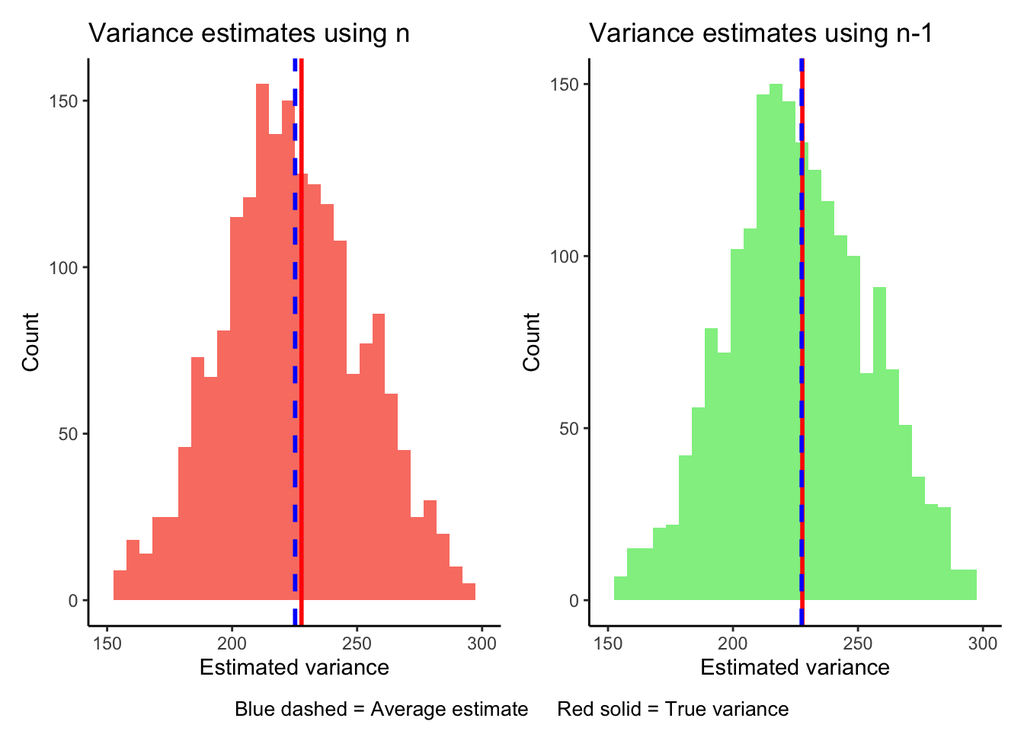

```r
library(ggplot2)
library(patchwork)

# Plot 1
p1 <- ggplot(data.frame(variance = variance_n), aes(x = variance)) +
  geom_histogram(fill = "salmon", color = NA, bins = 30) +
  geom_vline(xintercept = pop_variance, color = "red", linewidth = 1) +
  geom_vline(xintercept = avg_variance_n, color = "blue", linewidth = 1, linetype = "dashed") +
  xlim(150, 300) +
  labs(title = "Variance estimates using n", x = "Estimated variance", y = "Count") +
  theme_classic()

# Plot 2
p2 <- ggplot(data.frame(variance = variance_n1), aes(x = variance)) +
  geom_histogram(fill = "lightgreen", color = NA, bins = 30) +
  geom_vline(xintercept = pop_variance, color = "red", linewidth = 1) +
  geom_vline(xintercept = avg_variance_n1, color = "blue", linewidth = 1, linetype = "dashed") +
  xlim(150, 300) +
  labs(title = "Variance estimates using n-1", x = "Estimated variance", y = "Count") +
  theme_classic()

# Show plots side by side
(p1 | p2) + plot_annotation(
  caption = "Blue dashed = Average estimate     Red solid = True variance",
  theme = theme(plot.caption = element_text(hjust = 0.5, size = 10))
)
```

# 3. Z-scores: Standardizing Data

Z-scores allow us to express values in terms of standard deviations from the mean, making it easier to identify unusual observations.

## Load Crime Data

```r
# Load crime data (using built-in USArrests dataset)
data("USArrests")

# Extract violent crime data
violent_crime <- USArrests$Murder + USArrests$Assault / 10  # Approximate violent crime rate
states <- rownames(USArrests)

# Create data frame
crime_data <- data.frame(
  state = states,
  violent = violent_crime
)

head(crime_data)
```

```
##        state violent
## 1    Alabama    36.8
## 2     Alaska    36.3
## 3    Arizona    37.5
## 4   Arkansas    27.8
## 5 California    36.6
## 6   Colorado    28.3
```

## Calculate Z-scores

```r
# Function to calculate z-scores
calculate_z <- function(x) {
  (x - mean(x)) / sd(x)
}

# Calculate z-scores for violent crime
crime_data$violent_z <- calculate_z(crime_data$violent)

# Summary statistics
cat("Violent Crime Statistics:\n")
```

```
## Violent Crime Statistics:
```

```r
cat("Mean:", round(mean(crime_data$violent), 2), "\n")
```

```
## Mean: 24.86
```

```r
cat("SD:", round(sd(crime_data$violent), 2), "\n\n")
```

```
## SD: 12.11
```

```r
# Look at a few states
cat("Selected States:\n")
```

```
## Selected States:
```

```r
selected <- c("California", "New York", "Texas", "Alaska", "Vermont")
for (state in selected) {
  idx <- which(crime_data$state == state)
  cat(sprintf("%s: Raw = %.2f, Z-score = %.2f\n",
              state,
              crime_data$violent[idx],
              crime_data$violent_z[idx]))
}
```

```
## California: Raw = 36.60, Z-score = 0.97
## New York: Raw = 36.50, Z-score = 0.96
## Texas: Raw = 32.80, Z-score = 0.66
## Alaska: Raw = 36.30, Z-score = 0.94
## Vermont: Raw = 7.00, Z-score = -1.48
```

## Visualizing All States

Note: I haven’t used ggplot here but I always recommend using ggplot because it is easier to customize!

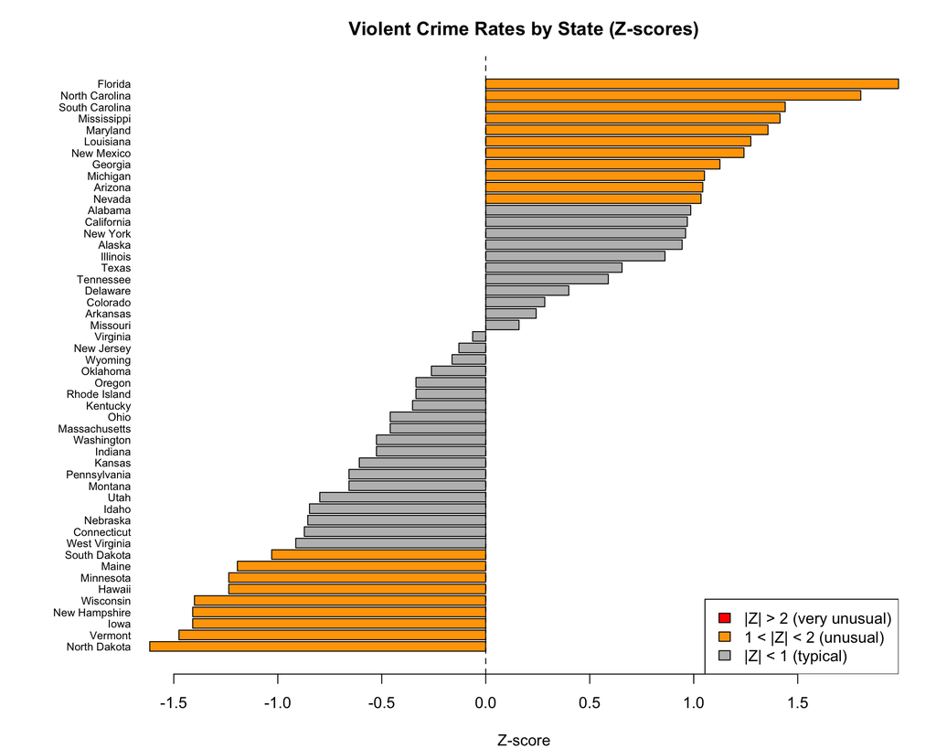

```r
# Create a sorted plot of all states
crime_data_sorted <- crime_data[order(crime_data$violent_z), ]
crime_data_sorted$rank <- 1:nrow(crime_data_sorted)

# Color code by z-score magnitude
colors <- ifelse(abs(crime_data_sorted$violent_z) > 2, "red",
                 ifelse(abs(crime_data_sorted$violent_z) > 1, "orange", "gray"))

# Create plot
par(mar = c(4, 8, 3, 2))
barplot(crime_data_sorted$violent_z,
        names.arg = crime_data_sorted$state,
        horiz = TRUE,
        las = 1,
        col = colors,
        main = "Violent Crime Rates by State (Z-scores)",
        xlab = "Z-score",
        cex.names = 0.7)
abline(v = c(-2, 0, 2), lty = c(3, 2, 3), col = c("blue", "black", "blue"))
legend("bottomright",
       c("|Z| > 2 (very unusual)", "1 < |Z| < 2 (unusual)", "|Z| < 1 (typical)"),
       fill = c("red", "orange", "gray"))
```

**Interpretation:** - States in gray are within 1 SD of the mean (typical) - States in orange are 1-2 SD from mean (unusual) - States in red are beyond 2 SD (very unusual and we actually don’t have any in our data).

# 4. Practice Exercises

Try these on your own:

1. **Calculate variability measures** for this dataset:

```r
reaction_times <- c(245, 267, 289, 298, 301, 315, 323, 356, 389, 412)

# Your code here:
# - Calculate range
# - Calculate IQR
# - Calculate variance and SD
```

2. **Z-score interpretation**: If a student scores 85 on a test where the mean is 75 and SD is 8:

```r
# Calculate their z-score

# What percentile are they approximately at?
# (Hint: about 68% of data is within 1 SD, 95% within 2 SD)
```

3. **Comparing variables**: Calculate z-scores for height (mean=170cm, SD=10cm) and weight (mean=70kg, SD=12kg). If person A is 185cm and 88kg, are they more unusual in height or weight?

```r
# Your code here
```

# Summary

**Key takeaways:**

- **Range** and **IQR** measure spread, with IQR being more robust to outliers
- **Variance** and **SD** quantify typical deviation from the mean
- Use **n-1** (not n) when calculating sample variance to get an unbiased estimate
- **Z-scores** standardize different variables to a common scale (mean=0, SD=1)